# trial1

Lukáš Hejtmánek

Thu Jul 09 00:31:38 2020

## Summative heatmaps

### ActiveAvoidance

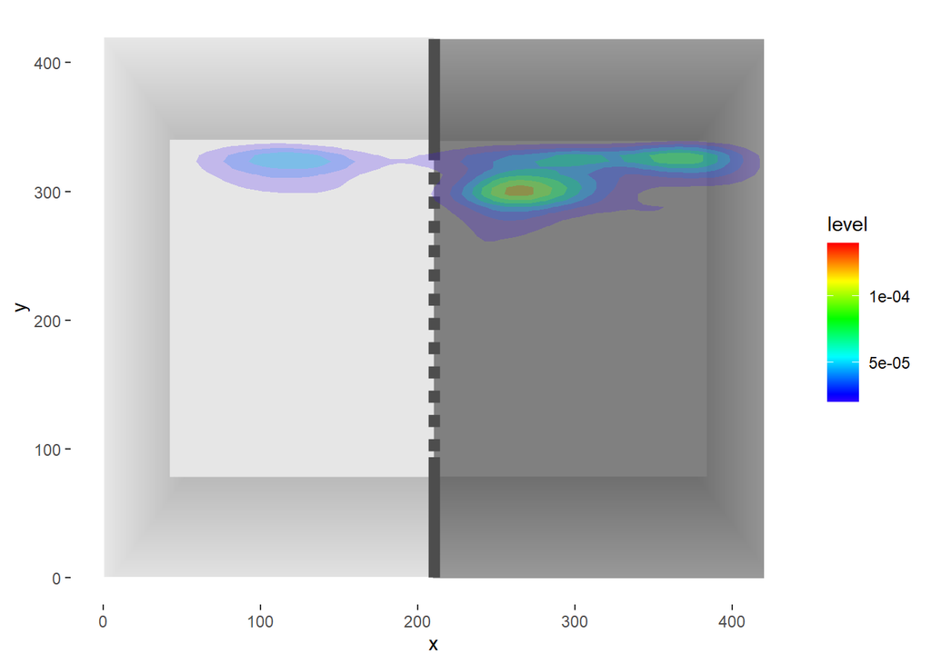

### LightDark Test

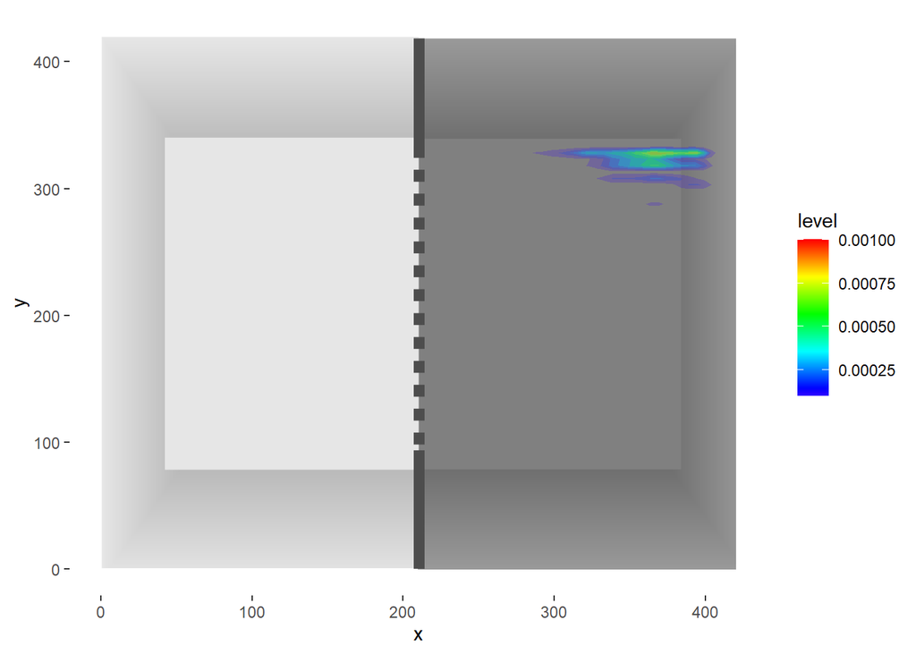

### ActiveAvoidance

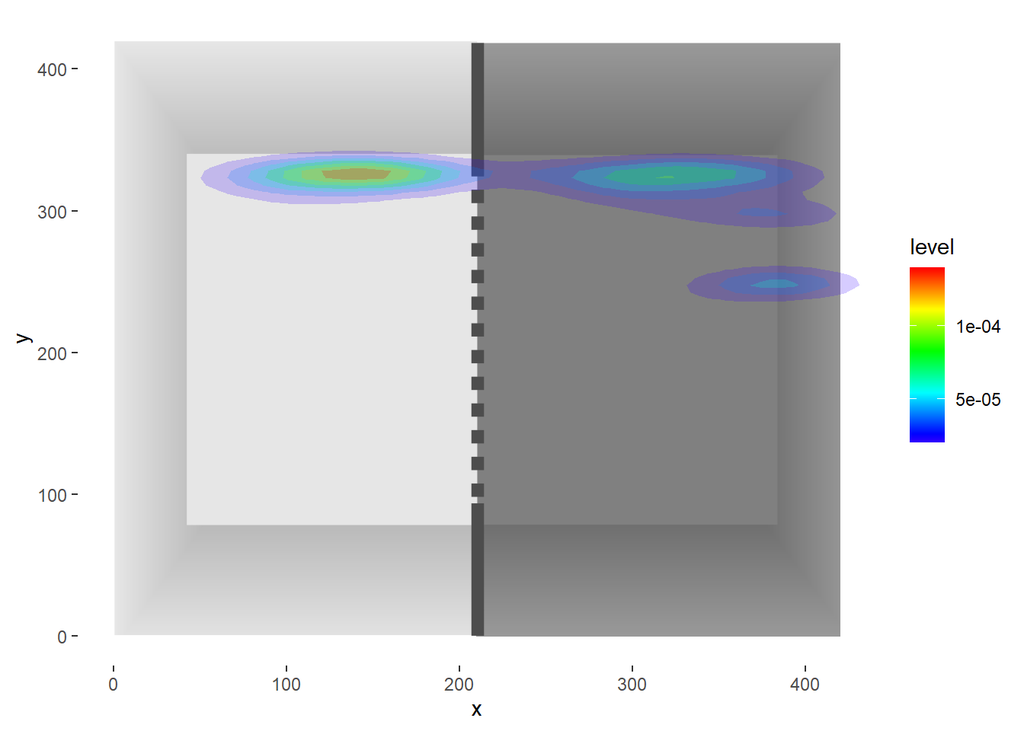

### LightDark Test

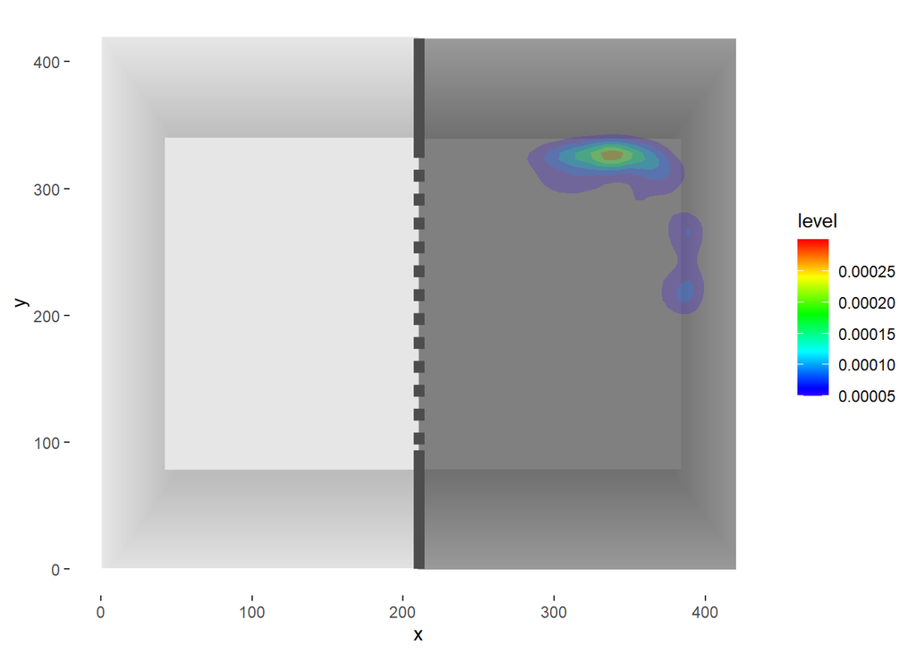

### Individual animals

[figure not shown]

Animal:

animal_1

Distance:

2226.04

Time in left zone:

NA

Time in right zone:

63.45

Time in central zone:

NA

Crosses to the right:

0

Crosses to the left:

0

Number of freezes:

0

Total freeze time:

0

Freeze time ratio:

0

[figure not shown]

Animal:

animal_1

Distance:

11262.89

Time in left zone:

NA

Time in right zone:

894.59

Time in central zone:

NA

Crosses to the right:

0

Crosses to the left:

0

Number of freezes:

31

Total freeze time:

282.56

Freeze time ratio:

0.32

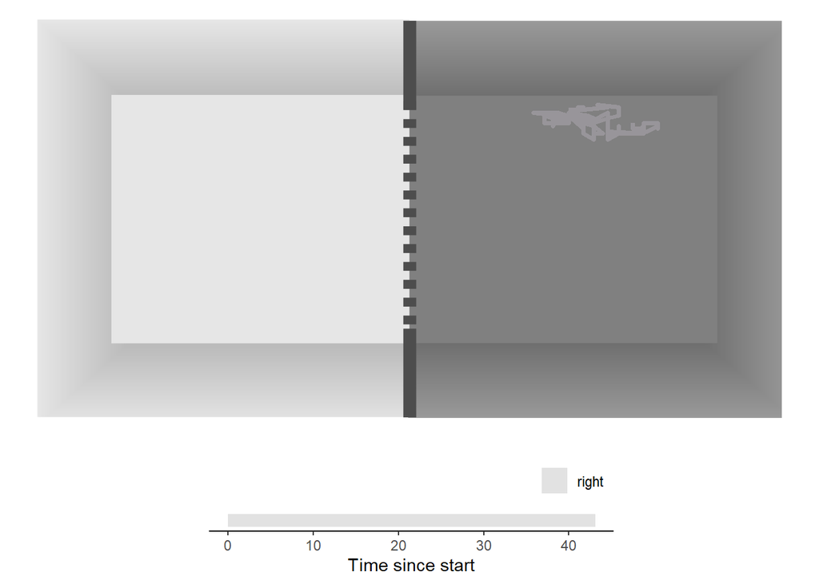

Animal:

animal_1

Distance:

846.55

Time in left zone:

NA

Time in right zone:

43.09

Time in central zone:

NA

Crosses to the right:

0

Crosses to the left:

0

Number of freezes:

1

Total freeze time:

9.19

Freeze time ratio:

0.21

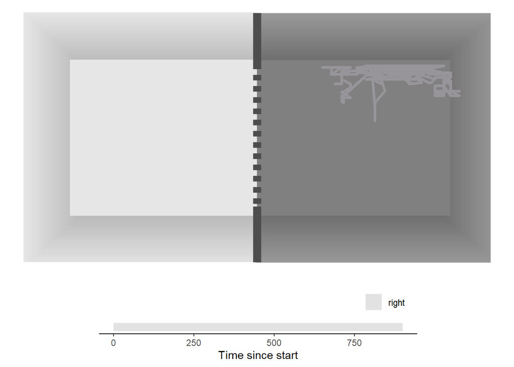

Animal:

animal_1

Distance:

16197.43

Time in left zone:

NA

Time in right zone:

899.92

Time in central zone:

NA

Crosses to the right:

0

Crosses to the left:

0

Number of freezes:

19

Total freeze time:

136.07

Freeze time ratio:

0.15

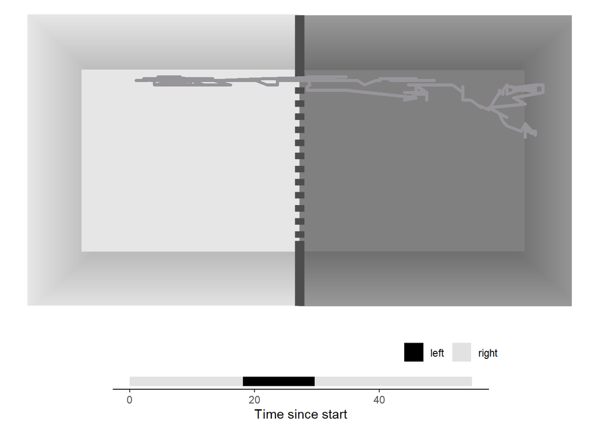

Animal:

animal_10

Distance:

2277.95

Time in left zone:

10.64

Time in right zone:

42.85

Time in central zone:

1.35

Crosses to the right:

1

Crosses to the left:

1

Number of freezes:

0

Total freeze time:

0

Freeze time ratio:

0

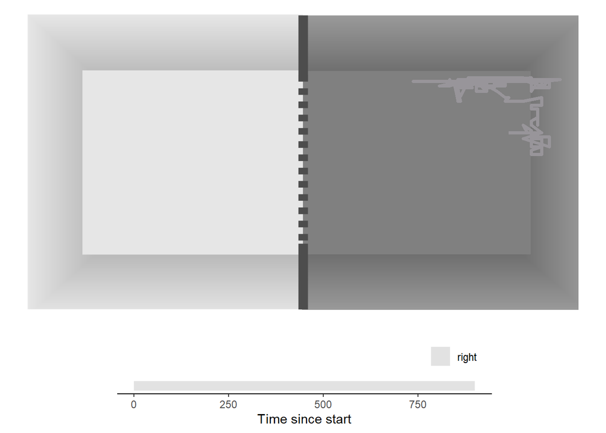

Animal:

animal_10

Distance:

9866.87

Time in left zone:

NA

Time in right zone:

899.74

Time in central zone:

NA

Crosses to the right:

0

Crosses to the left:

0

Number of freezes:

13

Total freeze time:

280.48

Freeze time ratio:

0.31

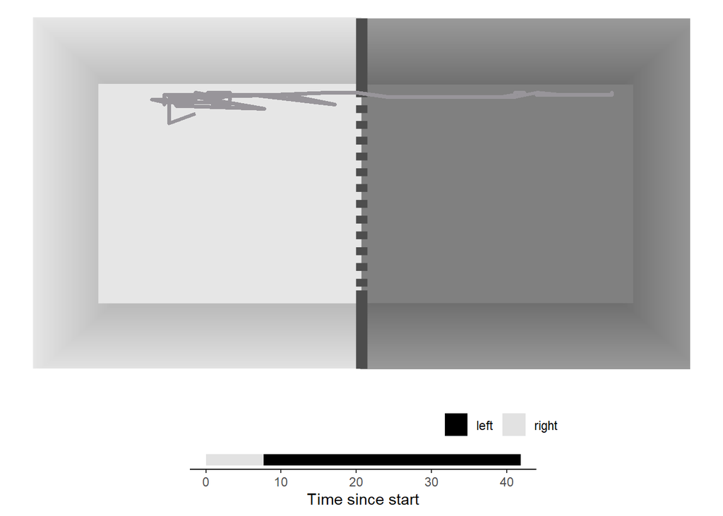

Animal:

animal_10

Distance:

1427.43

Time in left zone:

34.05

Time in right zone:

7.43

Time in central zone:

0.33

Crosses to the right:

0

Crosses to the left:

1

Number of freezes:

0

Total freeze time:

0

Freeze time ratio:

0

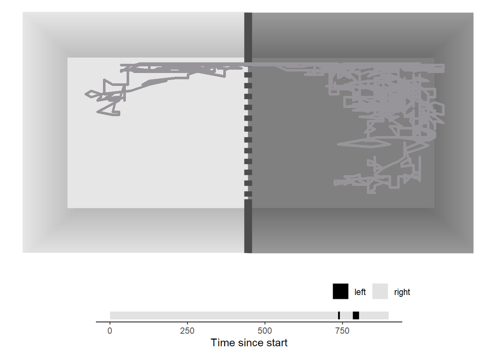

Animal:

animal_10

Distance:

17525.6

Time in left zone:

25.32

Time in right zone:

870.62

Time in central zone:

3.12

Crosses to the right:

2

Crosses to the left:

2

Number of freezes:

16

Total freeze time:

111

Freeze time ratio:

0.12

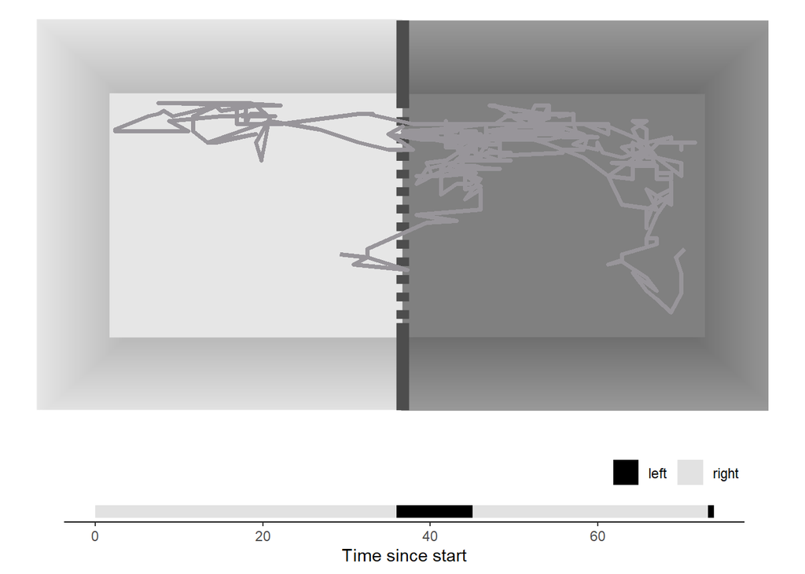

Animal:

animal_2

Distance:

5639.98

Time in left zone:

8.39

Time in right zone:

62.28

Time in central zone:

3.14

Crosses to the right:

1

Crosses to the left:

2

Number of freezes:

0

Total freeze time:

0

Freeze time ratio:

0

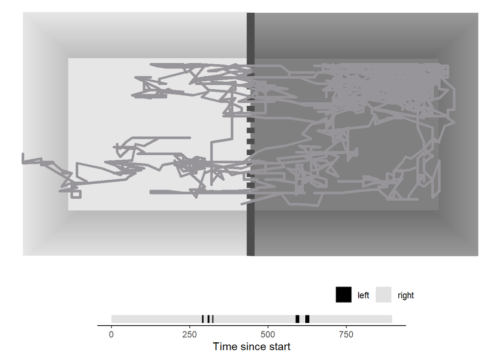

Animal:

animal_2

Distance:

32721.46

Time in left zone:

34.84

Time in right zone:

851.21

Time in central zone:

10.4

Crosses to the right:

7

Crosses to the left:

7

Number of freezes:

12

Total freeze time:

50.51

Freeze time ratio:

0.06

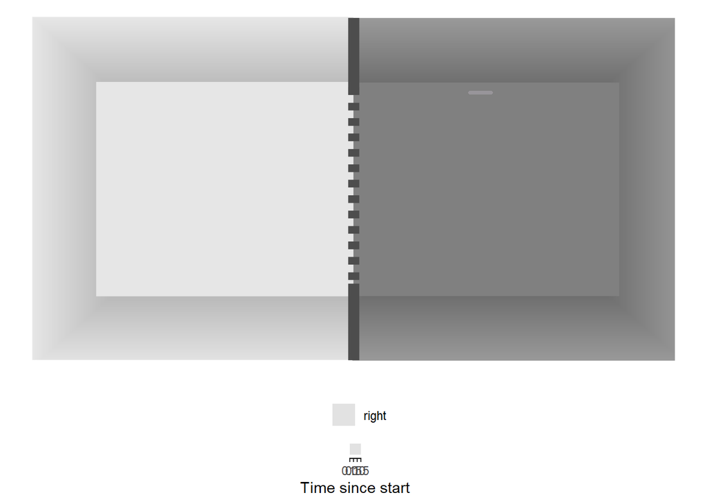

Animal:

animal_2

Distance:

36

Time in left zone:

NA

Time in right zone:

1.49

Time in central zone:

NA

Crosses to the right:

0

Crosses to the left:

0

Number of freezes:

0

Total freeze time:

0

Freeze time ratio:

0

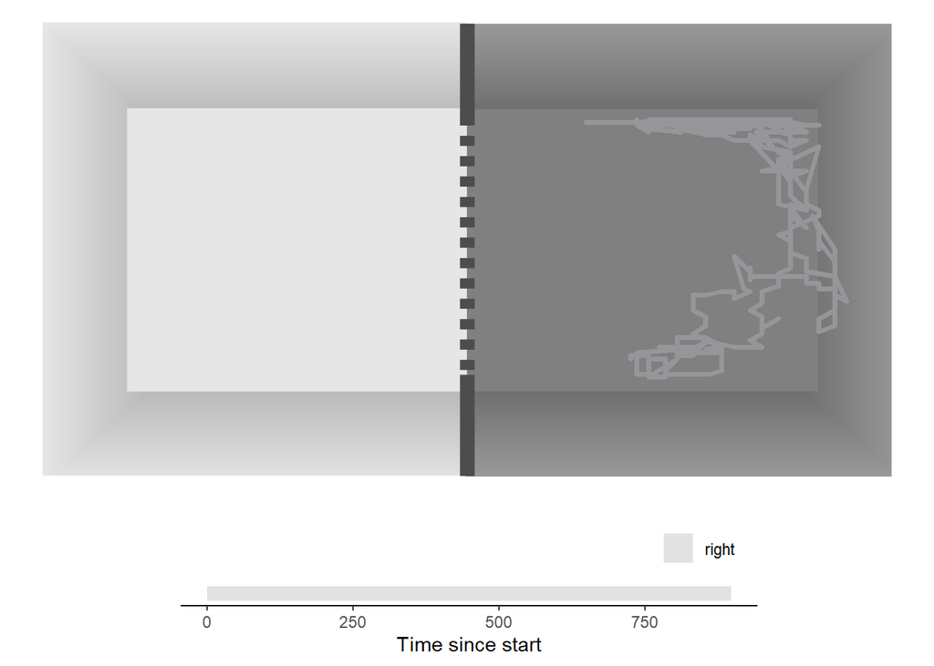

Animal:

animal_2

Distance:

13452.17

Time in left zone:

NA

Time in right zone:

898.11

Time in central zone:

NA

Crosses to the right:

0

Crosses to the left:

0

Number of freezes:

15

Total freeze time:

290.07

Freeze time ratio:

0.32

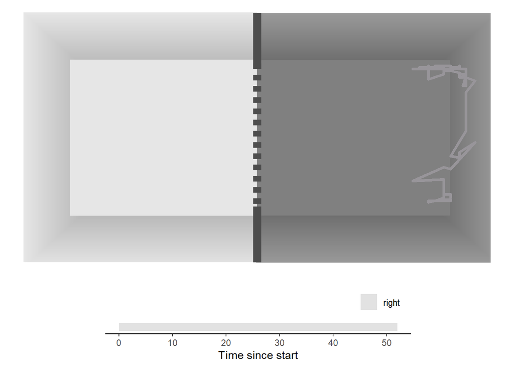

Animal:

animal_3

Distance:

1048.07

Time in left zone:

NA

Time in right zone:

51.97

Time in central zone:

NA

Crosses to the right:

0

Crosses to the left:

0

Number of freezes:

2

Total freeze time:

7.06

Freeze time ratio:

0.14

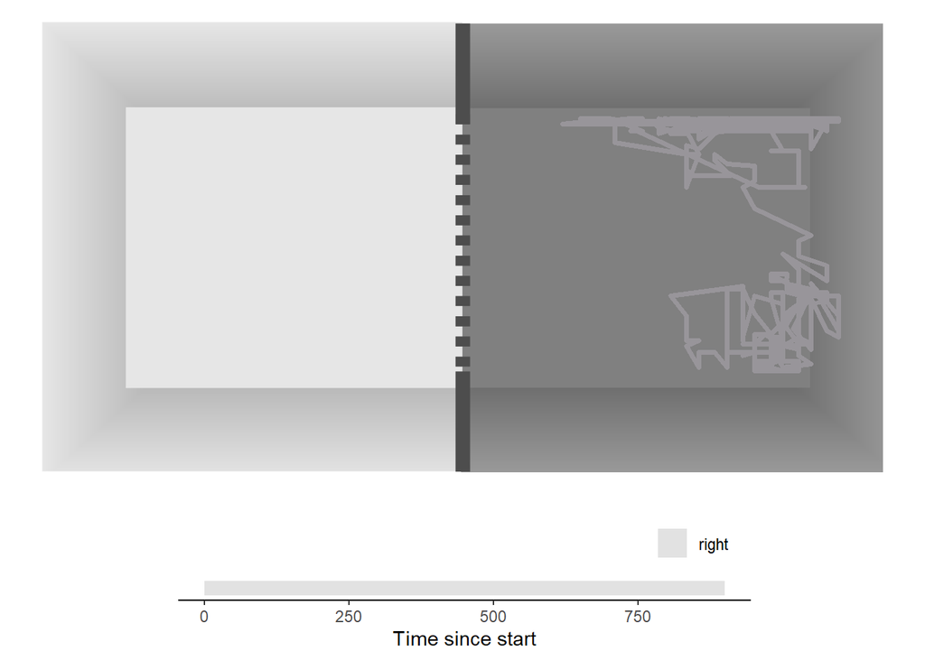

Animal:

animal_3

Distance:

11052.26

Time in left zone:

NA

Time in right zone:

899.89

Time in central zone:

NA

Crosses to the right:

0

Crosses to the left:

0

Number of freezes:

43

Total freeze time:

446.33

Freeze time ratio:

0.5

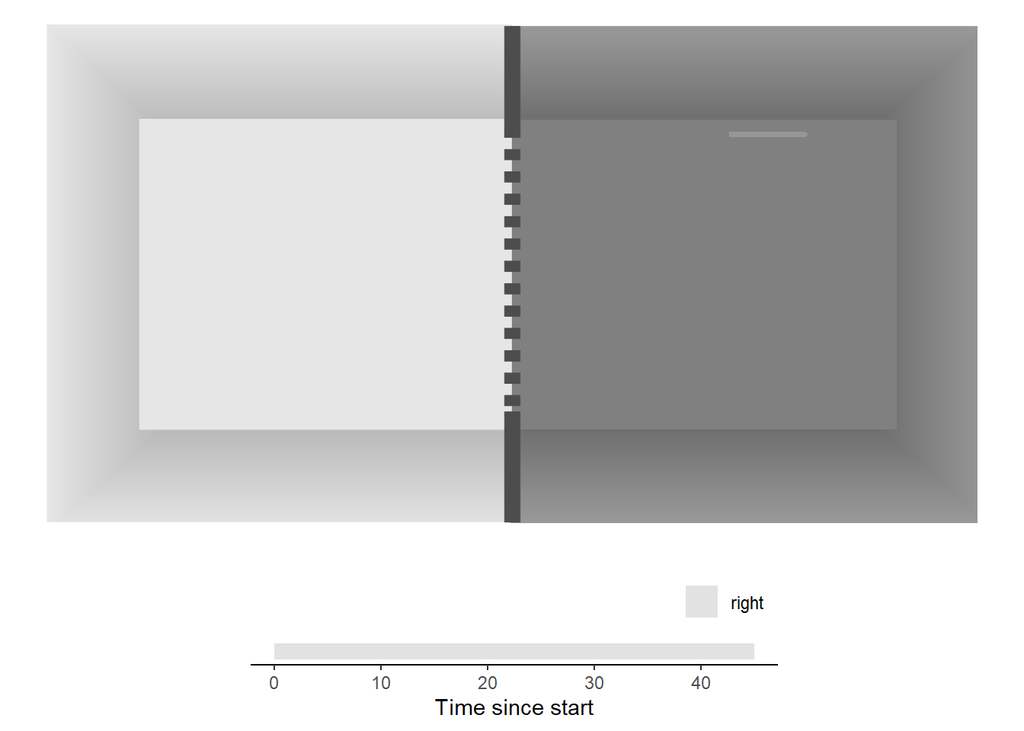

Animal:

animal_3

Distance:

266

Time in left zone:

NA

Time in right zone:

44.97

Time in central zone:

NA

Crosses to the right:

0

Crosses to the left:

0

Number of freezes:

1

Total freeze time:

7.73

Freeze time ratio:

0.17

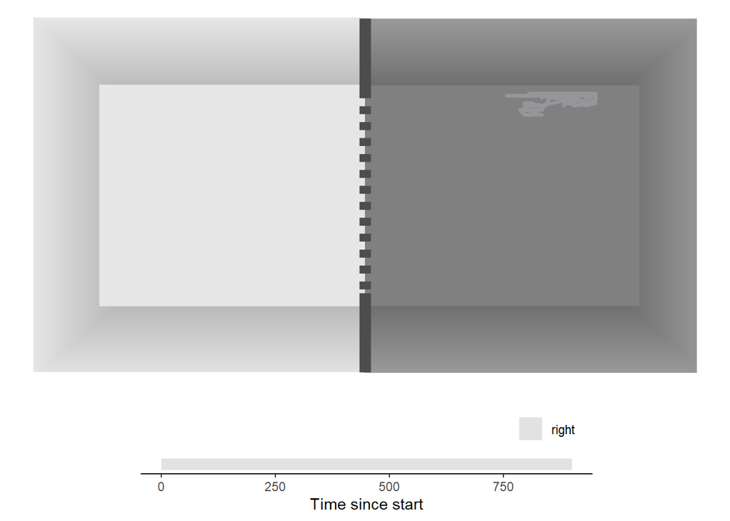

Animal:

animal_3

Distance:

3919.35

Time in left zone:

NA

Time in right zone:

899.96

Time in central zone:

NA

Crosses to the right:

0

Crosses to the left:

0

Number of freezes:

22

Total freeze time:

566.61

Freeze time ratio:

0.63

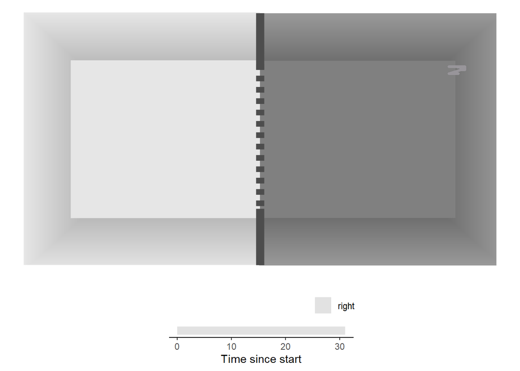

Animal:

animal_4

Distance:

72.78

Time in left zone:

NA

Time in right zone:

30.96

Time in central zone:

NA

Crosses to the right:

0

Crosses to the left:

0

Number of freezes:

2

Total freeze time:

25.88

Freeze time ratio:

0.84

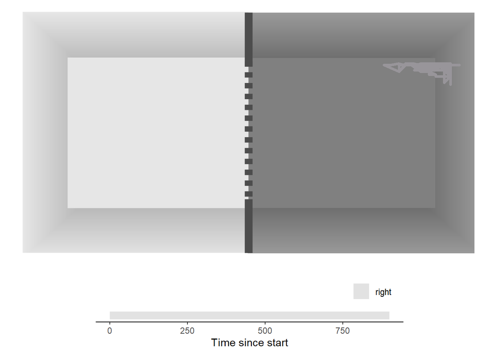

Animal:

animal_4

Distance:

5436.19

Time in left zone:

NA

Time in right zone:

899.98

Time in central zone:

NA

Crosses to the right:

0

Crosses to the left:

0

Number of freezes:

37

Total freeze time:

505.59

Freeze time ratio:

0.56

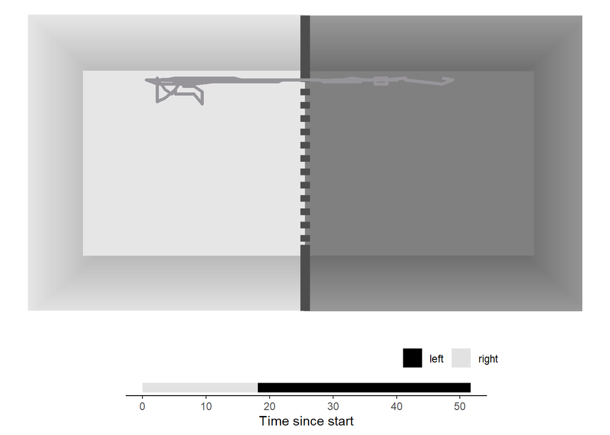

Animal:

animal_4

Distance:

1987.83

Time in left zone:

33.27

Time in right zone:

17.72

Time in central zone:

0.67

Crosses to the right:

0

Crosses to the left:

1

Number of freezes:

0

Total freeze time:

0

Freeze time ratio:

0

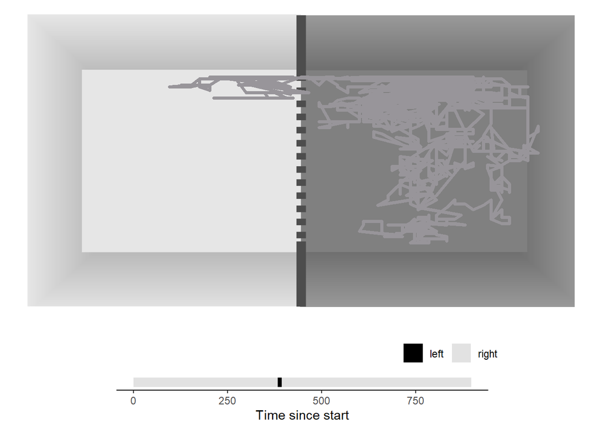

Animal:

animal_4

Distance:

28314.93

Time in left zone:

9.08

Time in right zone:

884.44

Time in central zone:

4.36

Crosses to the right:

1

Crosses to the left:

1

Number of freezes:

8

Total freeze time:

71

Freeze time ratio:

0.08

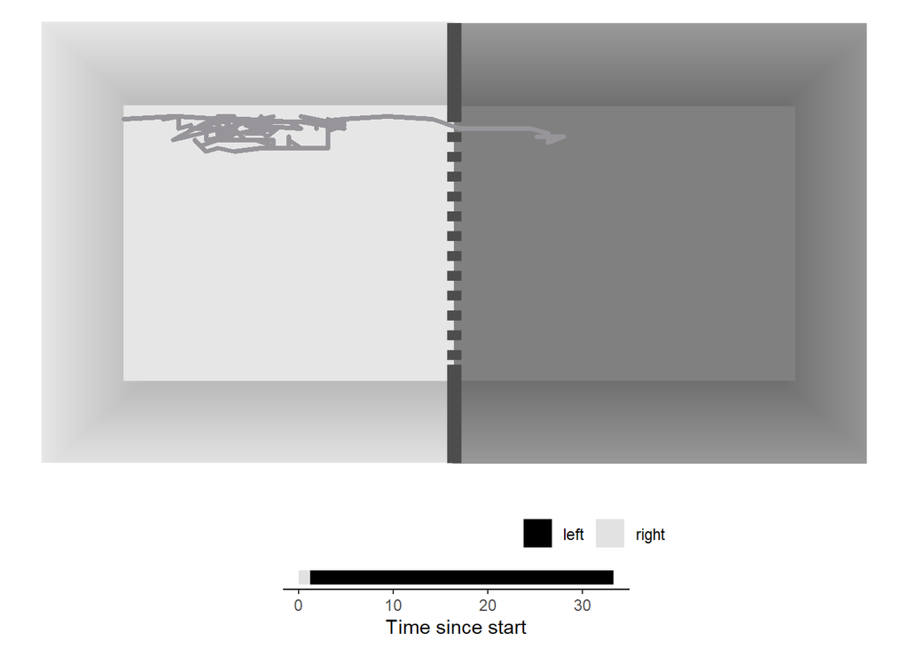

Animal:

animal_5

Distance:

1281.33

Time in left zone:

32.14

Time in right zone:

0.97

Time in central zone:

0.22

Crosses to the right:

0

Crosses to the left:

1

Number of freezes:

0

Total freeze time:

0

Freeze time ratio:

0

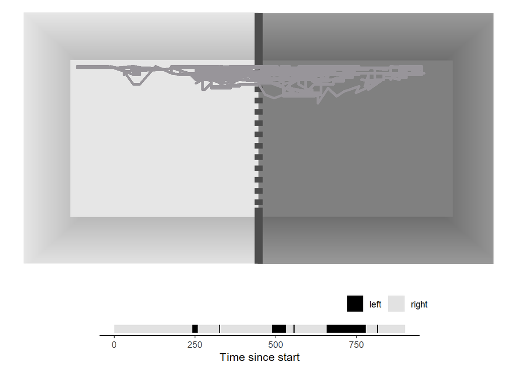

Animal:

animal_5

Distance:

14336.14

Time in left zone:

93.87

Time in right zone:

702.46

Time in central zone:

103.67

Crosses to the right:

6

Crosses to the left:

6

Number of freezes:

24

Total freeze time:

386.49

Freeze time ratio:

0.43

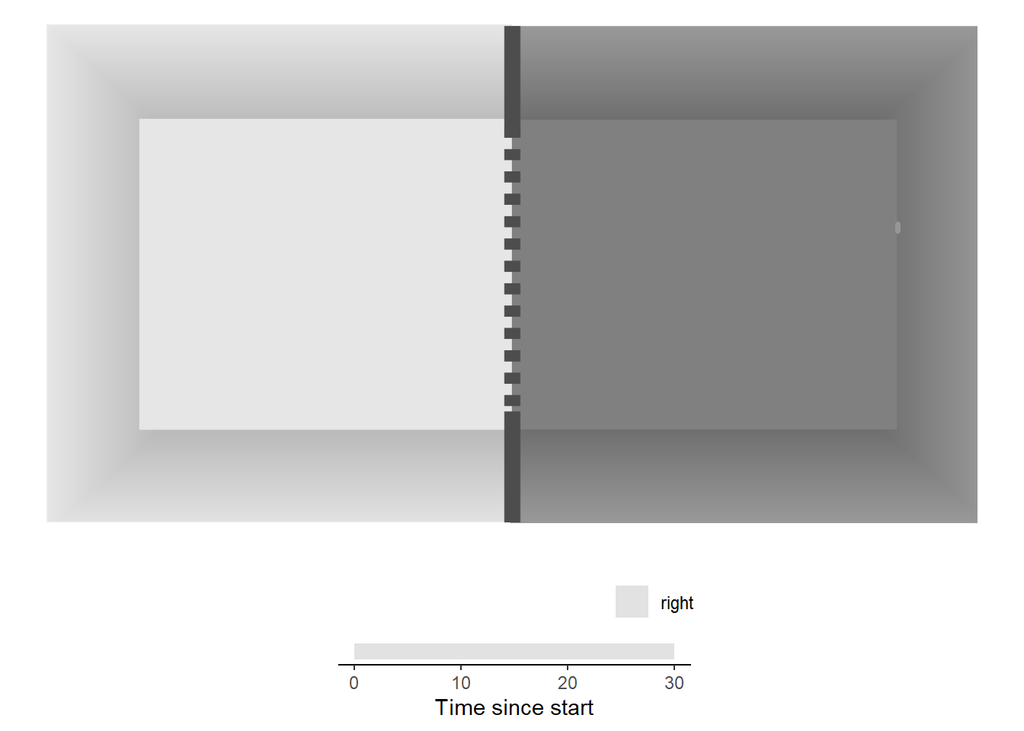

Animal:

animal_5

Distance:

510

Time in left zone:

NA

Time in right zone:

30.05

Time in central zone:

NA

Crosses to the right:

0

Crosses to the left:

0

Number of freezes:

0

Total freeze time:

0

Freeze time ratio:

0

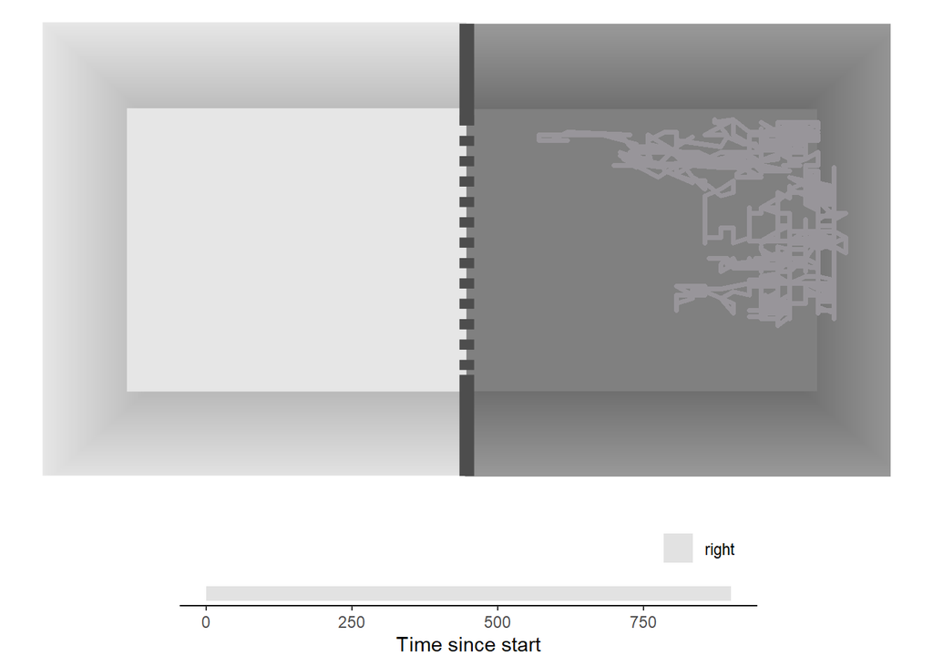

Animal:

animal_5

Distance:

12754.37

Time in left zone:

NA

Time in right zone:

899.97

Time in central zone:

NA

Crosses to the right:

0

Crosses to the left:

0

Number of freezes:

15

Total freeze time:

206.1

Freeze time ratio:

0.23

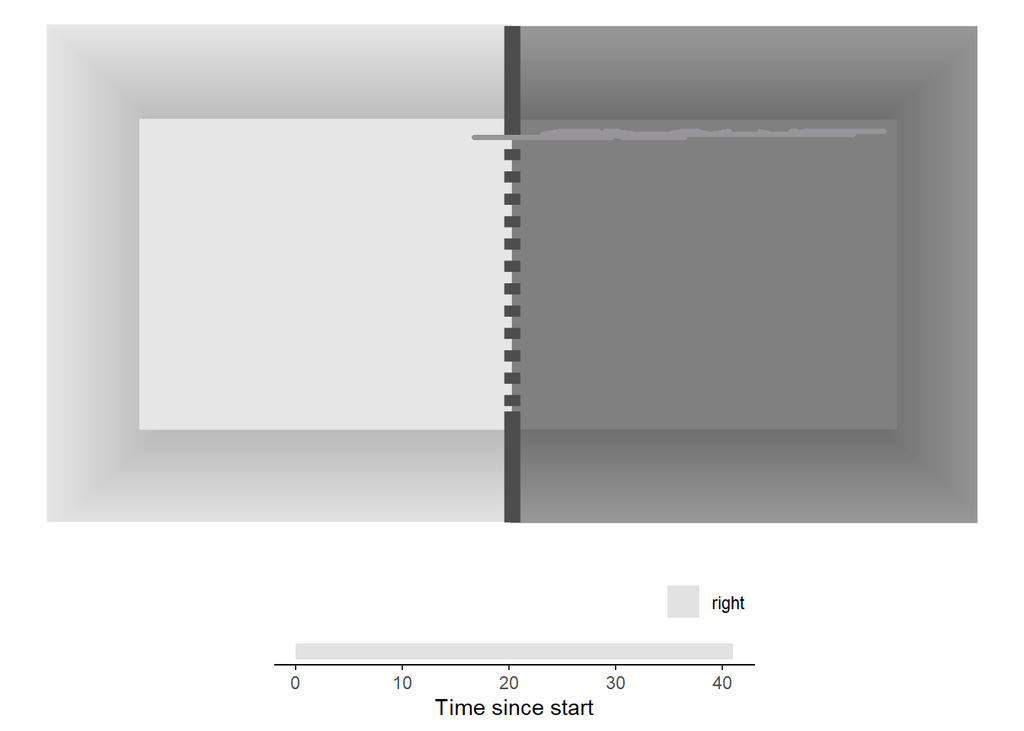

Animal:

animal_6

Distance:

941.55

Time in left zone:

NA

Time in right zone:

39.4

Time in central zone:

1.57

Crosses to the right:

0

Crosses to the left:

0

Number of freezes:

1

Total freeze time:

10.2

Freeze time ratio:

0.25

[figure not shown]

Animal:

animal_6

Distance:

10755.2

Time in left zone:

NA

Time in right zone:

778.42

Time in central zone:

NA

Crosses to the right:

0

Crosses to the left:

0

Number of freezes:

10

Total freeze time:

394.36

Freeze time ratio:

0.51

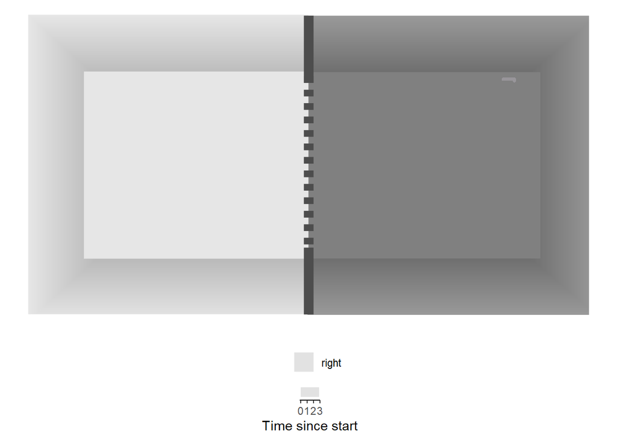

Animal:

animal_6

Distance:

16

Time in left zone:

NA

Time in right zone:

2.9

Time in central zone:

NA

Crosses to the right:

0

Crosses to the left:

0

Number of freezes:

0

Total freeze time:

0

Freeze time ratio:

0

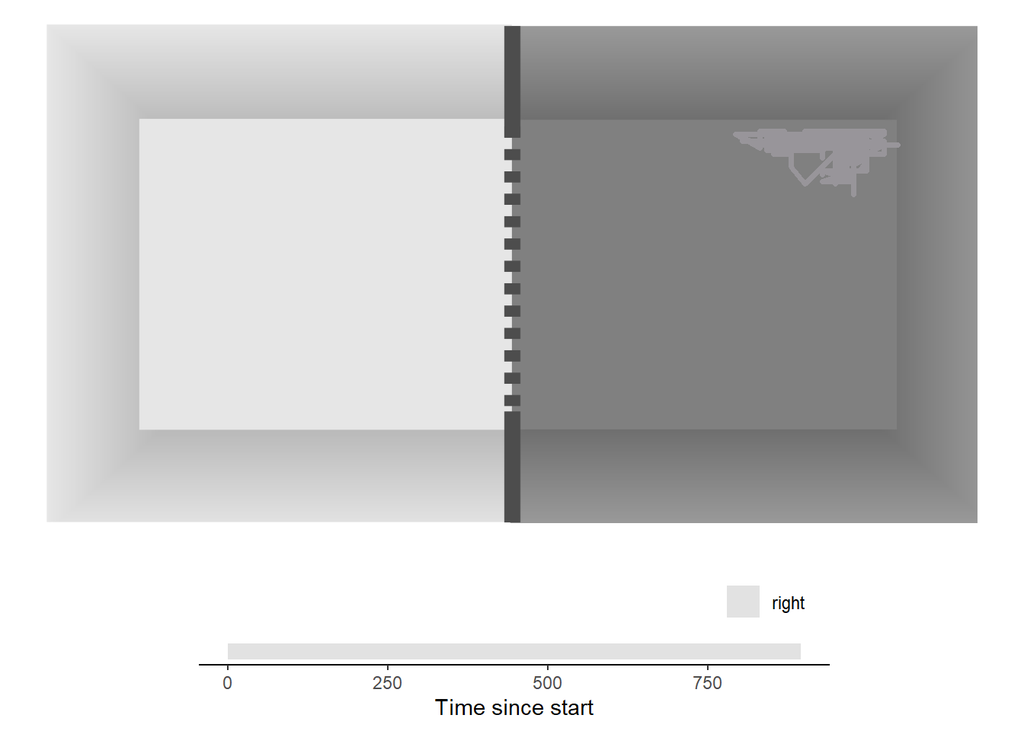

Animal:

animal_6

Distance:

11095.08

Time in left zone:

NA

Time in right zone:

895.98

Time in central zone:

NA

Crosses to the right:

0

Crosses to the left:

0

Number of freezes:

23

Total freeze time:

289.15

Freeze time ratio:

0.32

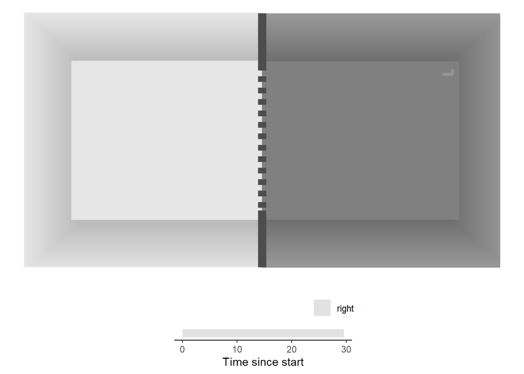

Animal:

animal_7

Distance:

48

Time in left zone:

NA

Time in right zone:

29.59

Time in central zone:

NA

Crosses to the right:

0

Crosses to the left:

0

Number of freezes:

1

Total freeze time:

20.16

Freeze time ratio:

0.68

[figure not shown]

Animal:

animal_7

Distance:

11292.71

Time in left zone:

NA

Time in right zone:

897.6

Time in central zone:

NA

Crosses to the right:

0

Crosses to the left:

0

Number of freezes:

37

Total freeze time:

408.83

Freeze time ratio:

0.46

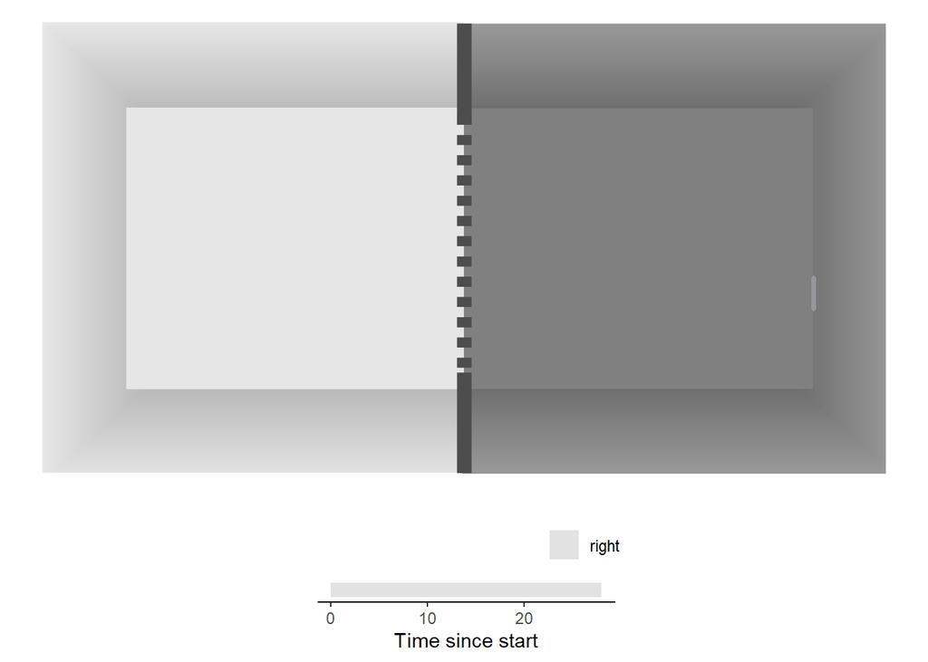

Animal:

animal_7

Distance:

160

Time in left zone:

NA

Time in right zone:

28

Time in central zone:

NA

Crosses to the right:

0

Crosses to the left:

0

Number of freezes:

0

Total freeze time:

0

Freeze time ratio:

0

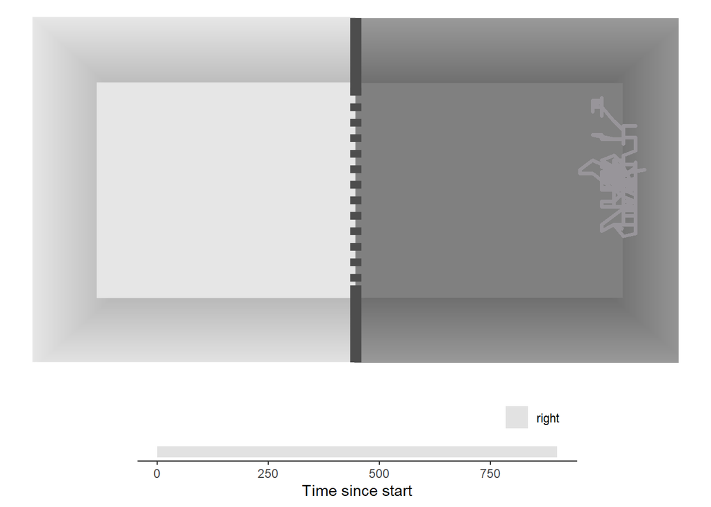

Animal:

animal_7

Distance:

7410.28

Time in left zone:

NA

Time in right zone:

899.57

Time in central zone:

NA

Crosses to the right:

0

Crosses to the left:

0

Number of freezes:

30

Total freeze time:

431.23

Freeze time ratio:

0.48

[figure not shown]

Animal:

animal_8

Distance:

298.55

Time in left zone:

NA

Time in right zone:

35.27

Time in central zone:

NA

Crosses to the right:

0

Crosses to the left:

0

Number of freezes:

1

Total freeze time:

23.3

Freeze time ratio:

0.66

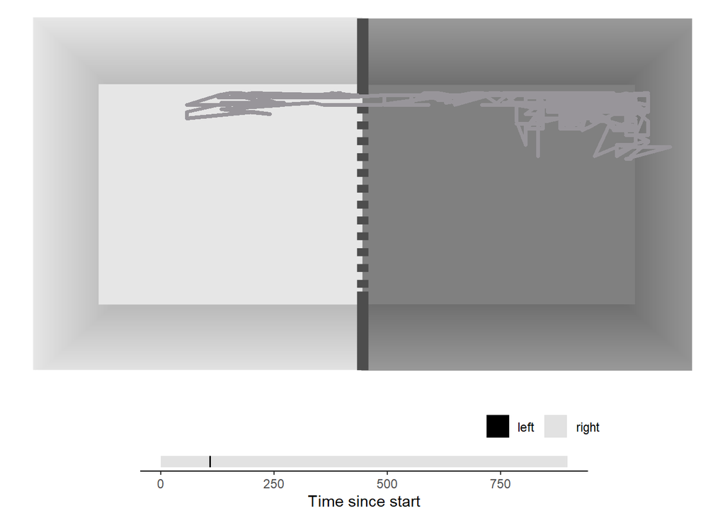

Animal:

animal_8

Distance:

18614.86

Time in left zone:

3.37

Time in right zone:

892.84

Time in central zone:

2.23

Crosses to the right:

1

Crosses to the left:

1

Number of freezes:

17

Total freeze time:

228.83

Freeze time ratio:

0.25

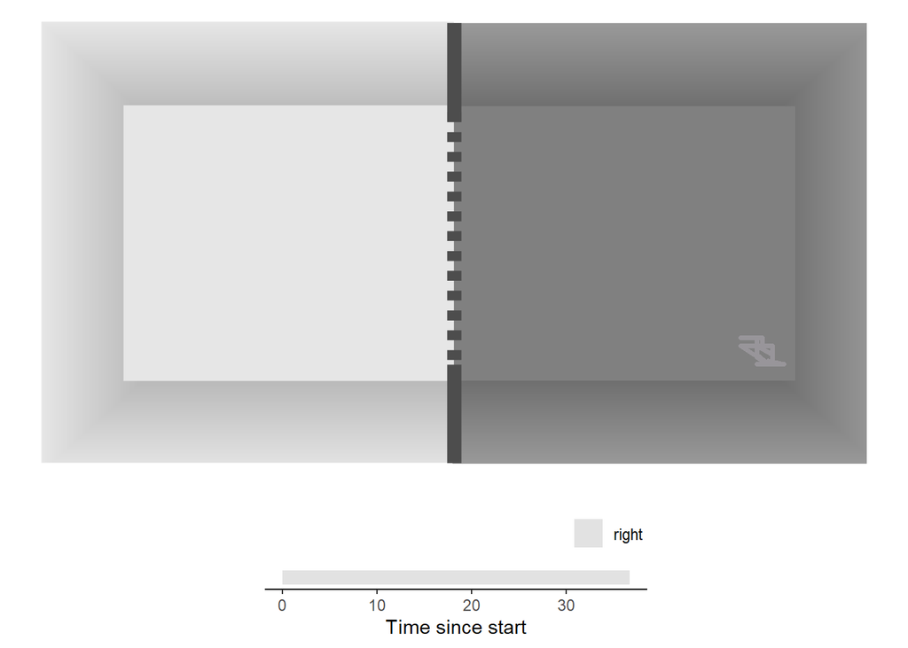

Animal:

animal_8

Distance:

291.18

Time in left zone:

NA

Time in right zone:

36.76

Time in central zone:

NA

Crosses to the right:

0

Crosses to the left:

0

Number of freezes:

0

Total freeze time:

0

Freeze time ratio:

0

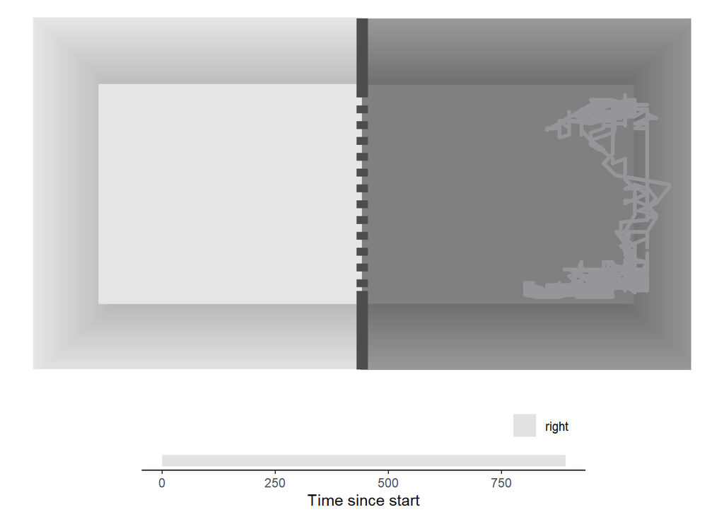

Animal:

animal_8

Distance:

9950.99

Time in left zone:

NA

Time in right zone:

891.76

Time in central zone:

NA

Crosses to the right:

0

Crosses to the left:

0

Number of freezes:

19

Total freeze time:

469.03

Freeze time ratio:

0.53

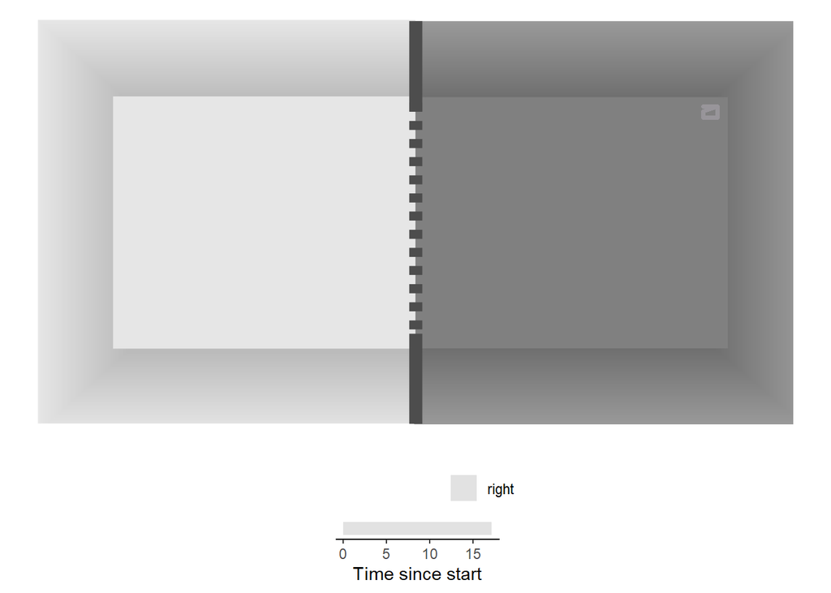

Animal:

animal_9

Distance:

66.43

Time in left zone:

NA

Time in right zone:

17.19

Time in central zone:

NA

Crosses to the right:

0

Crosses to the left:

0

Number of freezes:

2

Total freeze time:

7.62

Freeze time ratio:

0.44

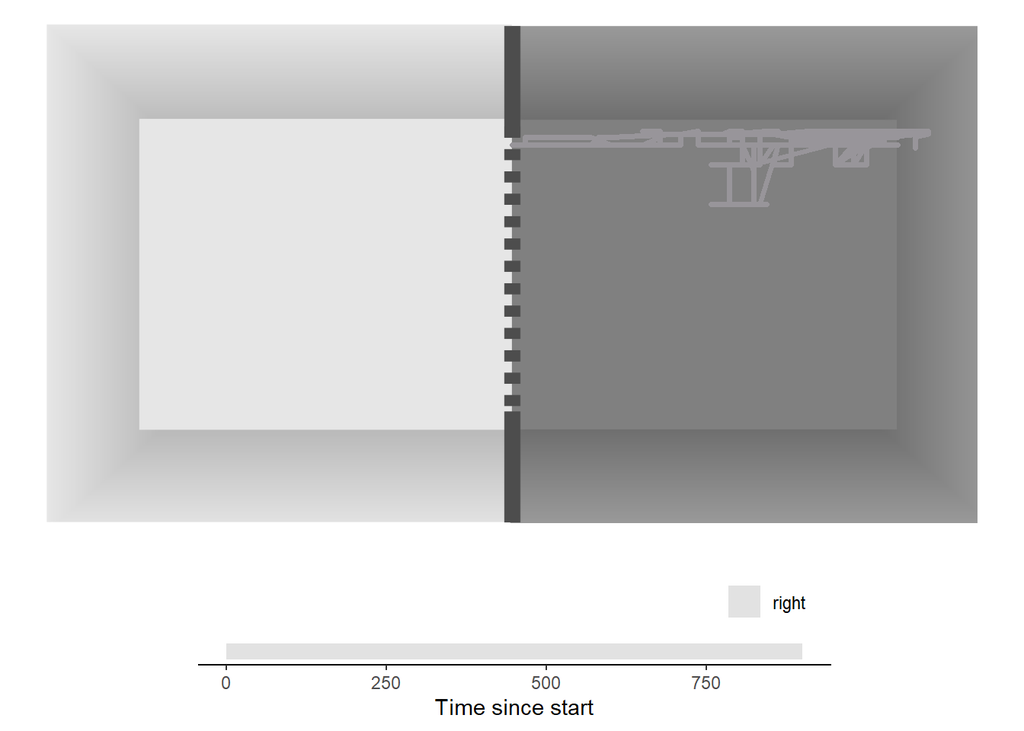

Animal:

animal_9

Distance:

10818.3

Time in left zone:

NA

Time in right zone:

899.03

Time in central zone:

0.68

Crosses to the right:

0

Crosses to the left:

0

Number of freezes:

26

Total freeze time:

204.55

Freeze time ratio:

0.23

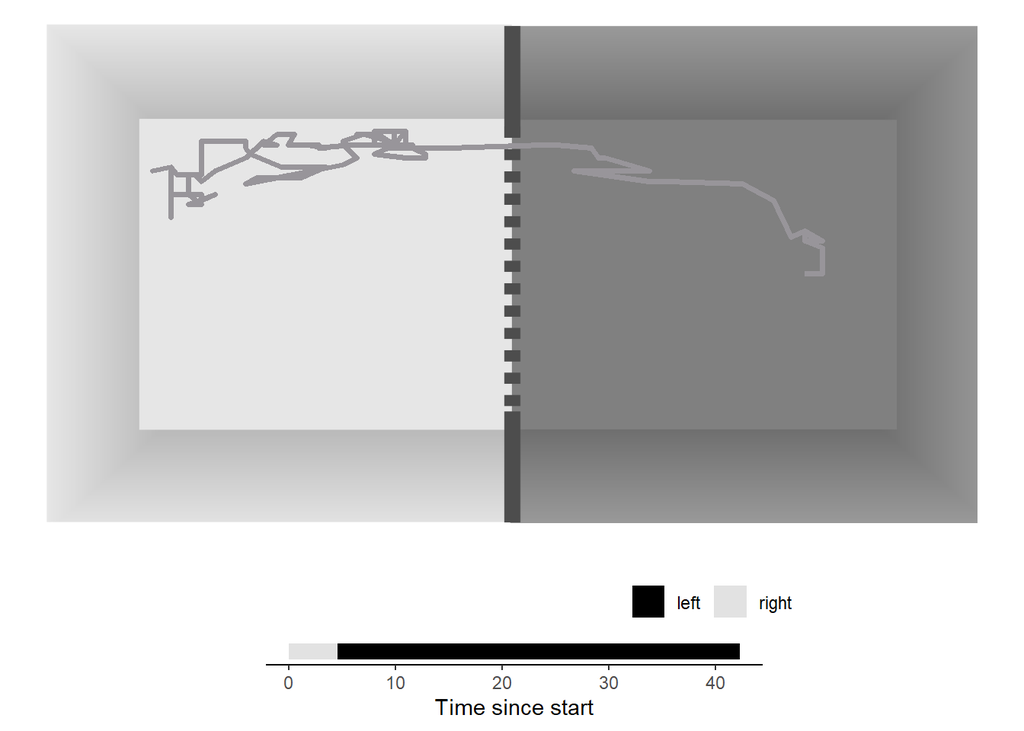

Animal:

animal_9

Distance:

1472.7

Time in left zone:

37.74

Time in right zone:

4.46

Time in central zone:

0.11

Crosses to the right:

0

Crosses to the left:

1

Number of freezes:

1

Total freeze time:

2.13

Freeze time ratio:

0.05

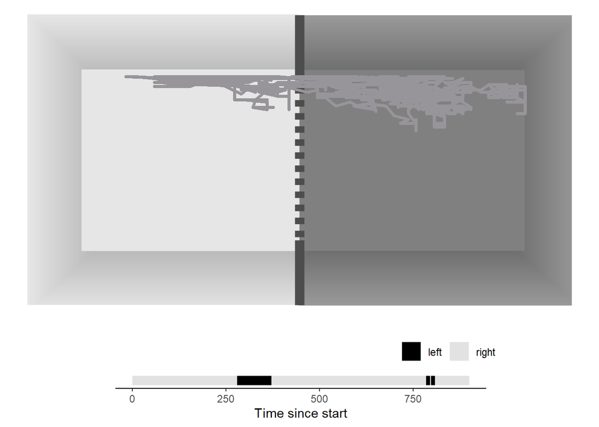

Animal:

animal_9

Distance:

17371.47

Time in left zone:

103.63

Time in right zone:

782.55

Time in central zone:

13.75

Crosses to the right:

3

Crosses to the left:

3

Number of freezes:

17

Total freeze time:

243.92

Freeze time ratio:

0.27

## Summary statistics

Animal:

Distance:

1390.07

Time in left zone:

17.06

Time in right zone:

37.39

Time in central zone:

1.57

Crosses to the right:

0.2

Crosses to the left:

0.4

Number of freezes:

0.9

Total freeze time:

9.42

Freeze time ratio:

0.3

Animal:

Distance:

13615.69

Time in left zone:

44.03

Time in right zone:

861.58

Time in central zone:

29.24

Crosses to the right:

1.4

Crosses to the left:

1.4

Number of freezes:

25

Total freeze time:

318.85

Freeze time ratio:

0.36

Animal:

Distance:

701.37

Time in left zone:

35.02

Time in right zone:

21.69

Time in central zone:

0.37

Crosses to the right:

0

Crosses to the left:

0.3

Number of freezes:

0.3

Total freeze time:

1.9

Freeze time ratio:

0.04

Animal:

Distance:

13799.17

Time in left zone:

46.01

Time in right zone:

882.29

Time in central zone:

7.08

Crosses to the right:

0.6

Crosses to the left:

0.6

Number of freezes:

18.4

Total freeze time:

281.42

Freeze time ratio:

0.31